# Final Project, Part 2

A. Kramer

Wednesday, February 18, 2015

## Assignment

Now in the second portion of the class, we’re going to analyze the ToothGrowth data in the R datasets package.

```
1. Load the ToothGrowth data and perform some basic exploratory data analyses
2. Provide a basic summary of the data.
3. Use confidence intervals and/or hypothesis tests to compare tooth growth by supp and dose. (Only use the techniques from class, even if there's other approaches worth considering)
4. State your conclusions and the assumptions needed for your conclusions.
```

## Overview

The data framle loaded contains 60 observations on 3 variables. The variables are:

[output not shown]

## Solution

### Question 1: Load the ToothGrowth data and perform some basic exploratory data analyses

```r
library(datasets)
tmp <- ToothGrowth
str(tmp)
```

```
## 'data.frame':    60 obs. of  3 variables:
##  $ len : num  4.2 11.5 7.3 5.8 6.4 10 11.2 11.2 5.2 7 ...
##  $ supp: Factor w/ 2 levels "OJ","VC": 2 2 2 2 2 2 2 2 2 2 ...
##  $ dose: num  0.5 0.5 0.5 0.5 0.5 0.5 0.5 0.5 0.5 0.5 ...
```

Plotting tooth length vs. supplement and tooth length vs. dosage to visually investigate the relationships between the variables.

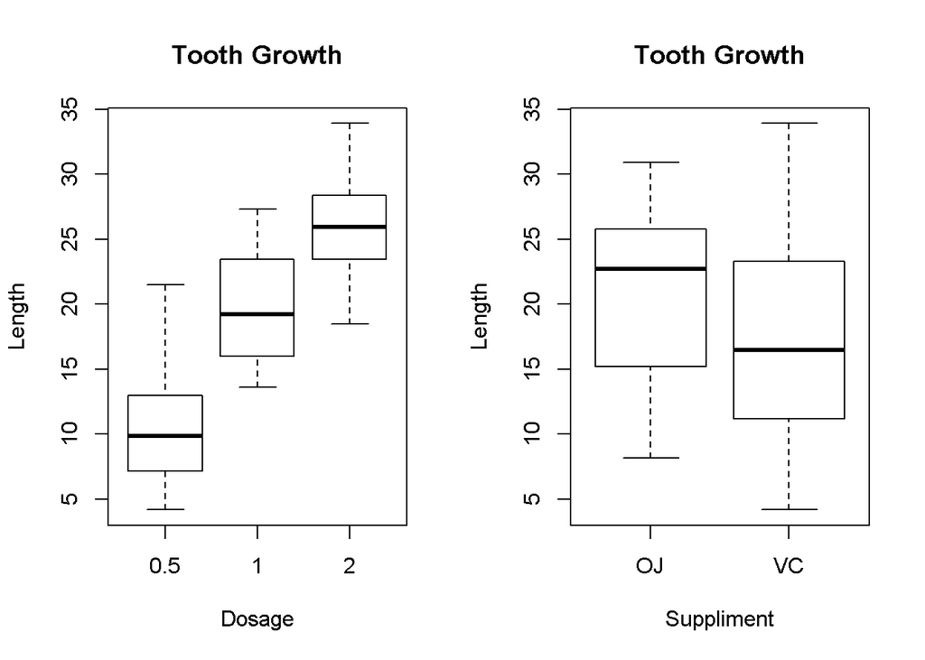

```r
par(mfrow=c(1,2))
boxplot(len~dose, data=tmp, xlab = "Dosage", ylab = "Length", main = "Tooth Growth")
boxplot(len~supp, data=tmp, xlab = "Suppliment", ylab = "Length", main = "Tooth Growth")
```

### Question 2: Provide a basic summary of the data.

```r
dim(tmp)
```

```
## [1] 60  3
```

```r
tmp$dose <- as.factor(tmp$dose)
summary(tmp)
```

```
##       len        supp     dose
##  Min.   : 4.20   OJ:30   0.5:20
##  1st Qu.:13.07   VC:30   1  :20
##  Median :19.25           2  :20
##  Mean   :18.81
##  3rd Qu.:25.27
##  Max.   :33.90
```

Displaying table of supplement and dosage usage in the data frame.

```r
table(tmp$dose, tmp$supp)
```

```
##
##       OJ VC
##   0.5 10 10
##   1   10 10
##   2   10 10
```

### Question 3: Use confidence intervals and/or hypothesis tests to compare tooth growth by supp and dose.

Calculating Confidance Intervals for equal and unequal variances.

```r
t1 <- t.test(len~supp, paired=F, var.equal=T, data=tmp)
t2 <- t.test(len~supp, paired=F, var.equal=F, data=tmp)
results = cbind(c(t1$p.value, t2$p.value), c(t1$conf[1],t2$conf[1]), c(t1$conf[2],t2$conf[2]))
colnames(results) <- c("P-Value", "Confidence Low", "Confidence High")
rownames(results) <- c("Equal Variances","Unequal Varariances")
results
```

```
##                        P-Value Confidence Low Confidence High
## Equal Variances     0.06039337     -0.1670064        7.567006
## Unequal Varariances 0.06063451     -0.1710156        7.571016
```